# CP07 - BMW vs VOLKSWAGEN

Carlos Serrano Valera

13/12/2020

## Introducción

El objetivo de este trabajo es realizar un modelo Causal Impact entre las series temporales del precio de la acción de las empresas BMW y Volkswagen. El proósito principal es estudiar el efecto del DieselGate

## Causal Impact

Estudiamos preliminarmente las series por separado. Hemos cogido muestras de Yahoo Finance para las dos empresas des el año 2014 hasta la actualidad.

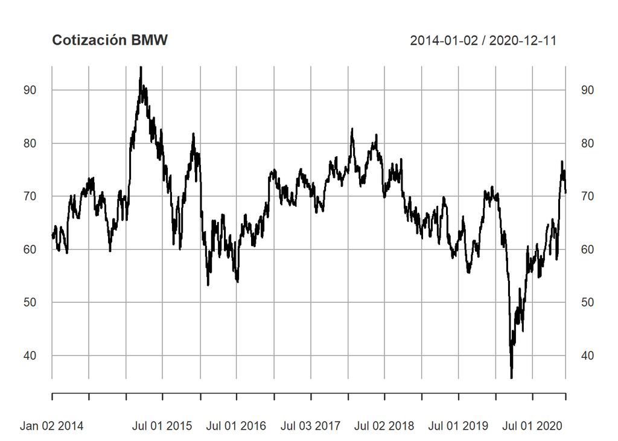

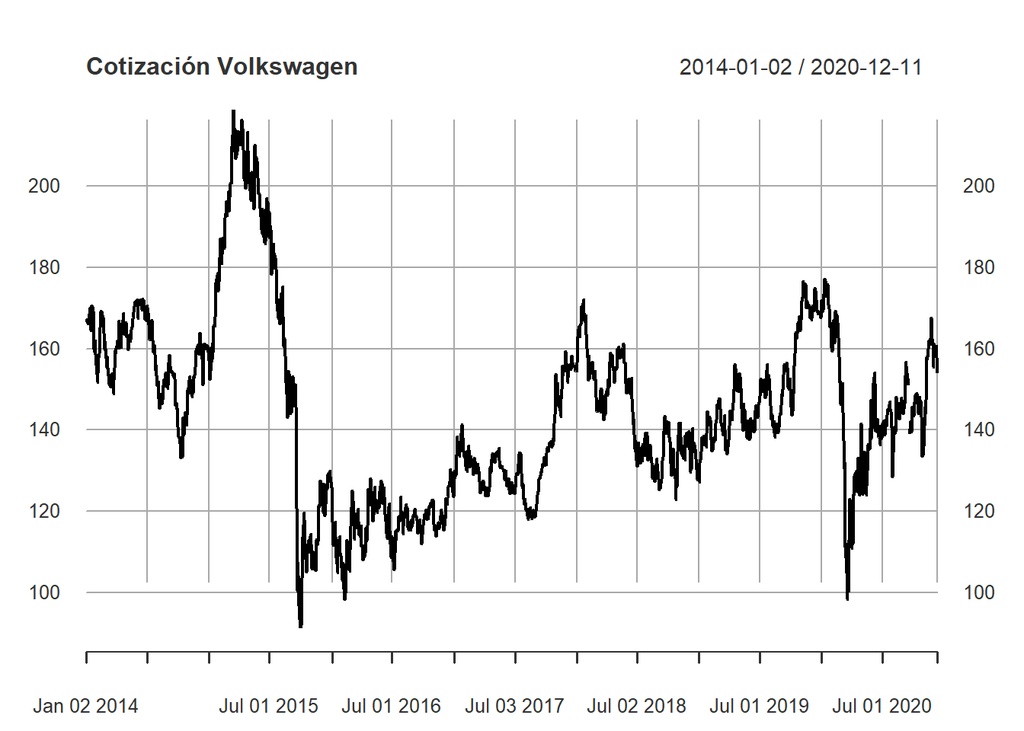

En septiembre de 2015, se descubrió el DieselGate, cuando se supo que Volkswagen había estado manipulando la emisión de Diesel de sus modelos para hacer parecer que eran menos contaminantes.

El modelo Causal Impact requiere un punto de corte. Se va a elgir el 1 de Septiembre de 2015 como tal.

```r
causal_vol <- CausalImpact(vol_bmw,
                             pre.period = pre_period,
                             post.period = post_period)
causal_bmw <- CausalImpact(bmw_vol,
                             pre.period = pre_period,
                             post.period = post_period)
```

```
## Posterior inference {CausalImpact}
##
##                          Average        Cumulative
## Actual                   136            182895
## Prediction (s.d.)        156 (16)       208460 (21652)
## 95% CI                   [124, 189]     [165794, 253127]
##
## Absolute effect (s.d.)   -19 (16)       -25565 (21652)
## 95% CI                   [-52, 13]      [-70232, 17101]
##
## Relative effect (s.d.)   -12% (10%)     -12% (10%)
## 95% CI                   [-34%, 8.2%]   [-34%, 8.2%]
##
## Posterior tail-area probability p:   0.11631
## Posterior prob. of a causal effect:  88%
##
## For more details, type: summary(impact, "report")
```

Podemos visualizar la estimación del modelo mediante un plot, en este caso para Volkswagen:

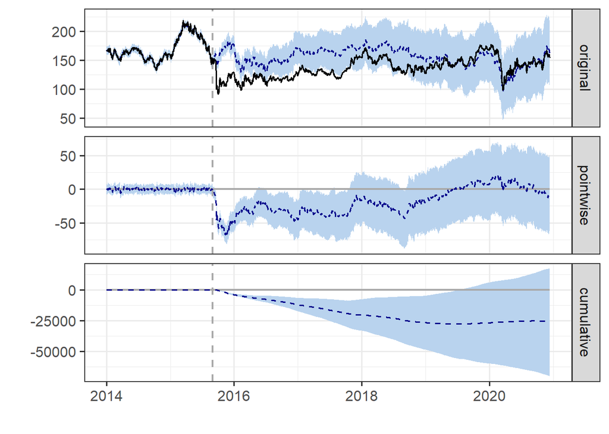

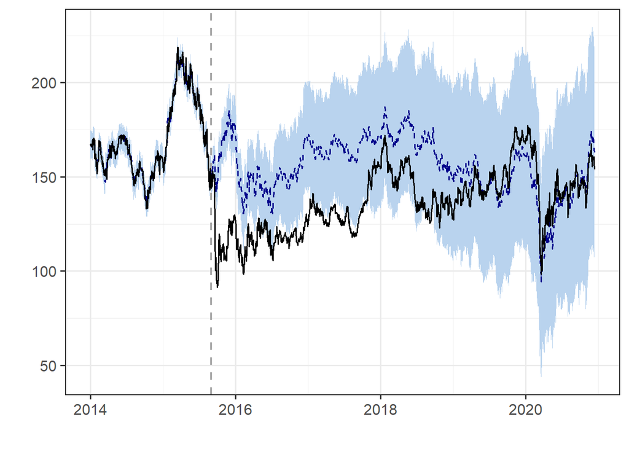

Aprovechando las herramientas de R, podemos obtener un informe generado de manera automática:

[output not shown]

Cabe señalar que, según el reporte extraído, el efecto provocado por el DieselGate no es estadísticamente significativo.

Ahora comprobamos qué sucedión con BMW

```
## Posterior inference {CausalImpact}
##
##                          Average       Cumulative
## Actual                   67            89362
## Prediction (s.d.)        60 (6.6)      80072 (8821.8)
## 95% CI                   [47, 73]      [63643, 98432]
##
## Absolute effect (s.d.)   6.9 (6.6)     9289.4 (8821.8)
## 95% CI                   [-6.8, 19]    [-9070.7, 25719]
##
## Relative effect (s.d.)   12% (11%)     12% (11%)
## 95% CI                   [-11%, 32%]   [-11%, 32%]
##
## Posterior tail-area probability p:   0.14842
## Posterior prob. of a causal effect:  85%
##
## For more details, type: summary(impact, "report")
```

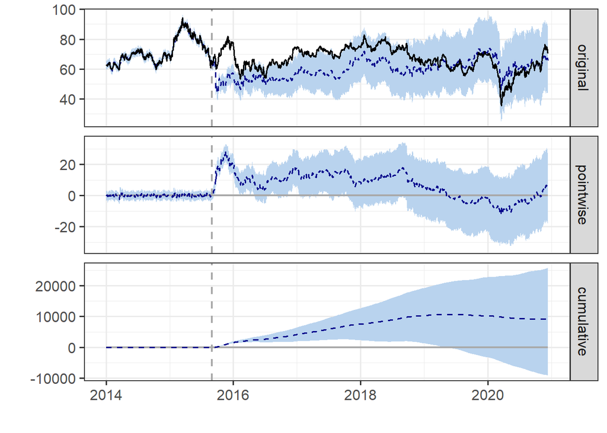

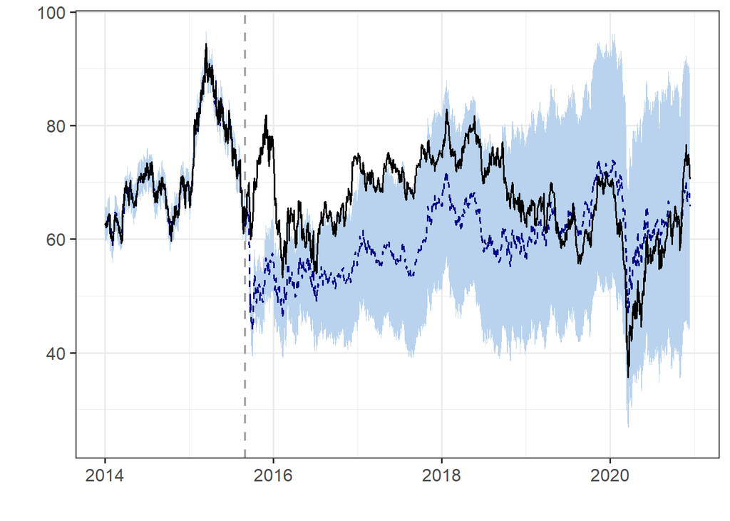

Se aprecia un efecto inverso originado por el escándalo de emisiones. Fue un impacto positivo para BMW.

[output not shown]

De nuevo, el efecto no es estadísticamente significativo.

## Conclusiones

Por otro lado, BMW se benefició de la caída de su competencia, y obtuvo un incremento en las cotizaciones.

En cualquier caso, se ha comprobado que ninguno de estos efectos fue estadísticamente significativo, aunque se intuye de las gráficas que el comportamiento de ambas empresas en el mercado habría sido ciertamente diferente de no ser por el DieselGate.